```python
import numpy as np
import pandas as pd
from sklearn import metrics as skmetrics
import matplotlib.pyplot as plt
import seaborn as sns

%matplotlib inline

from tensorflow import keras as ks
from tensorflow.keras import Sequential
from tensorflow.keras.layers import Dense
from tensorflow.keras.layers import Dropout
from tensorflow.keras import metrics
import keras.backend as K
```

# Reading Dataset and Feature Elimination

- Read the dataset properly - Print the overview of the data (statistical summary, shape, info, etc) - Eliminate the unique features from the dataset with proper reasoning

```python
from google.colab import drive
drive.mount('/content/drive')
```

```python
orig_data = pd.read_csv('/content/drive/MyDrive/data/bank.csv')
```

```python
data = orig_data.copy()
data.info()
```

```
<class 'pandas.core.frame.DataFrame'>
RangeIndex: 10000 entries, 0 to 9999
Data columns (total 14 columns):
 #   Column           Non-Null Count  Dtype
---  ------           --------------  -----
 0   RowNumber        10000 non-null  int64
 1   CustomerId       10000 non-null  int64
 2   Surname          10000 non-null  object
 3   CreditScore      10000 non-null  int64
 4   Geography        10000 non-null  object
 5   Gender           10000 non-null  object
 6   Age              10000 non-null  int64
 7   Tenure           10000 non-null  int64
 8   Balance          10000 non-null  float64
 9   NumOfProducts    10000 non-null  int64
 10  HasCrCard        10000 non-null  int64
 11  IsActiveMember   10000 non-null  int64
 12  EstimatedSalary  10000 non-null  float64
 13  Exited           10000 non-null  int64
dtypes: float64(2), int64(9), object(3)
memory usage: 1.1+ MB
```

```python
data.sample(10)
```

|  | RowNumber | CustomerId | Surname | CreditScore | Geography | Gender | Age | Tenure | Balance | NumOfProducts | HasCrCard | IsActiveMember | EstimatedSalary | Exited |
| --- | --- | --- | --- | --- | --- | --- | --- | --- | --- | --- | --- | --- | --- | --- |
| 2656 | 2657 | 15713267 | Zimmer | 779 | Spain | Female | 34 | 5 | 0.00 | 2 | 0 | 1 | 111676.63 | 0 |
| 445 | 446 | 15803406 | Ross | 748 | France | Female | 26 | 1 | 77780.29 | 1 | 0 | 1 | 183049.41 | 0 |
| 9505 | 9506 | 15571281 | Ts'ao | 651 | France | Male | 28 | 10 | 79562.98 | 1 | 1 | 1 | 74687.37 | 0 |
| 332 | 333 | 15702669 | Faulkner | 663 | Germany | Male | 44 | 2 | 117028.60 | 2 | 0 | 1 | 144680.18 | 0 |
| 4168 | 4169 | 15690796 | Chambers | 516 | France | Male | 37 | 8 | 0.00 | 1 | 1 | 0 | 101834.58 | 0 |
| 2364 | 2365 | 15796343 | Bazhenov | 707 | France | Female | 31 | 2 | 82787.93 | 2 | 0 | 0 | 91423.69 | 0 |
| 6097 | 6098 | 15615050 | Savage | 575 | Germany | Male | 47 | 9 | 107915.94 | 2 | 1 | 1 | 63452.18 | 1 |
| 7 | 8 | 15656148 | Obinna | 376 | Germany | Female | 29 | 4 | 115046.74 | 4 | 1 | 0 | 119346.88 | 1 |
| 7752 | 7753 | 15775307 | Sung | 490 | Spain | Female | 38 | 3 | 97266.10 | 1 | 1 | 1 | 92797.23 | 0 |
| 4453 | 4454 | 15775756 | Alexandrova | 809 | Germany | Male | 33 | 8 | 148055.74 | 1 | 0 | 0 | 199203.21 | 0 |

```python
data.Geography.value_counts()
```

```
France     5014
Germany    2509
Spain      2477
Name: Geography, dtype: int64
```

```python
data.Gender.value_counts()
```

```
Male      5457
Female    4543
Name: Gender, dtype: int64
```

```python
data.Surname.value_counts()[:20]
```

```
Smith       32
Scott       29
Martin      29
Walker      28
Brown       26
Shih        25
Genovese    25
Yeh         25
Maclean     24
Wright      24
Ma          23
Fanucci     23
White       23
Wilson      23
Lu          22
Moore       22
Johnson     22
Wang        22
Chu         22
Mai         21
Name: Surname, dtype: int64
```

```python
data.Surname.nunique()
```

```
2932
```

```python
data.RowNumber.nunique()
```

```
10000
```

```python
data.CustomerId.nunique()
```

```
10000
```

```python
data.Exited.value_counts()
```

```
0    7963
1    2037
Name: Exited, dtype: int64
```

```python
data.HasCrCard.value_counts()
```

```
1    7055
0    2945
Name: HasCrCard, dtype: int64
```

```python
data.IsActiveMember.value_counts()
```

```
1    5151
0    4849
Name: IsActiveMember, dtype: int64
```

```python
data.NumOfProducts.value_counts()
```

```
1    5084
2    4590
3     266
4      60
Name: NumOfProducts, dtype: int64
```

```python
data = data.drop(['Surname','RowNumber', 'CustomerId'], axis = 1)
```

```python
data.describe()
```

|  | CreditScore | Age | Tenure | Balance | NumOfProducts | HasCrCard | IsActiveMember | EstimatedSalary | Exited |
| --- | --- | --- | --- | --- | --- | --- | --- | --- | --- |
| count | 10000.000000 | 10000.000000 | 10000.000000 | 10000.000000 | 10000.000000 | 10000.00000 | 10000.000000 | 10000.000000 | 10000.000000 |
| mean | 650.528800 | 38.921800 | 5.012800 | 76485.889288 | 1.530200 | 0.70550 | 0.515100 | 100090.239881 | 0.203700 |
| std | 96.653299 | 10.487806 | 2.892174 | 62397.405202 | 0.581654 | 0.45584 | 0.499797 | 57510.492818 | 0.402769 |
| min | 350.000000 | 18.000000 | 0.000000 | 0.000000 | 1.000000 | 0.00000 | 0.000000 | 11.580000 | 0.000000 |
| 25% | 584.000000 | 32.000000 | 3.000000 | 0.000000 | 1.000000 | 0.00000 | 0.000000 | 51002.110000 | 0.000000 |
| 50% | 652.000000 | 37.000000 | 5.000000 | 97198.540000 | 1.000000 | 1.00000 | 1.000000 | 100193.915000 | 0.000000 |
| 75% | 718.000000 | 44.000000 | 7.000000 | 127644.240000 | 2.000000 | 1.00000 | 1.000000 | 149388.247500 | 0.000000 |
| max | 850.000000 | 92.000000 | 10.000000 | 250898.090000 | 4.000000 | 1.00000 | 1.000000 | 199992.480000 | 1.000000 |

# Perform an Exploratory Data Analysis on the data

- Bivariate analysis
- Use appropriate visualizations to identify the patterns and insights
- Come up with a customer profile (characteristics of a customer) of the different packages
- Any other exploratory deep dive

```python
data.columns
```

```
Index(['CreditScore', 'Geography', 'Gender', 'Age', 'Tenure', 'Balance',
       'NumOfProducts', 'HasCrCard', 'IsActiveMember', 'EstimatedSalary',
       'Exited'],
      dtype='object')
```

```python
categorical_columns = ['Geography', 'Gender', 'IsActiveMember', 'HasCrCard']
numerical_columns = ['CreditScore', 'Age', 'Tenure', 'Balance',
       'NumOfProducts', 'EstimatedSalary']
x_columns = ['CreditScore', 'Geography', 'Gender', 'Age', 'Tenure', 'Balance',
       'NumOfProducts', 'HasCrCard', 'IsActiveMember', 'EstimatedSalary']
y_column  = 'Exited'
```

## Univariate Analysis

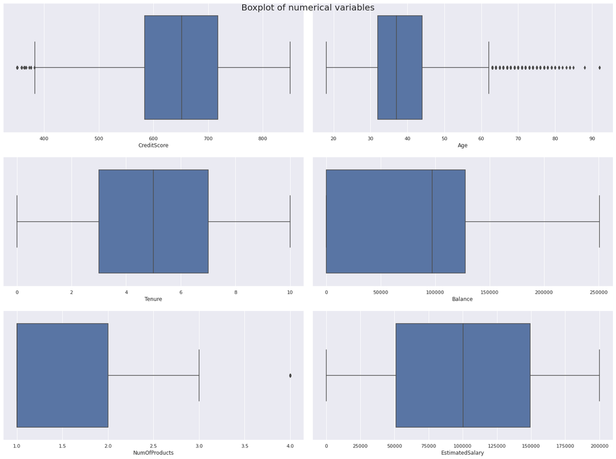

```python
fig, axes = plt.subplots(3, 2,  figsize=(20, 15))
fig.suptitle('Boxplot of numerical variables', fontsize=20)
counter = 0
for ii in range(3):
    sns.boxplot(ax=axes[ii][0],x=data[numerical_columns[counter]])
    counter = counter+1
    if counter != 6:
        sns.boxplot(ax=axes[ii][1],x=data[numerical_columns[counter]])
        counter = counter+1
    else:
        pass

fig.tight_layout(pad=2.0)
```

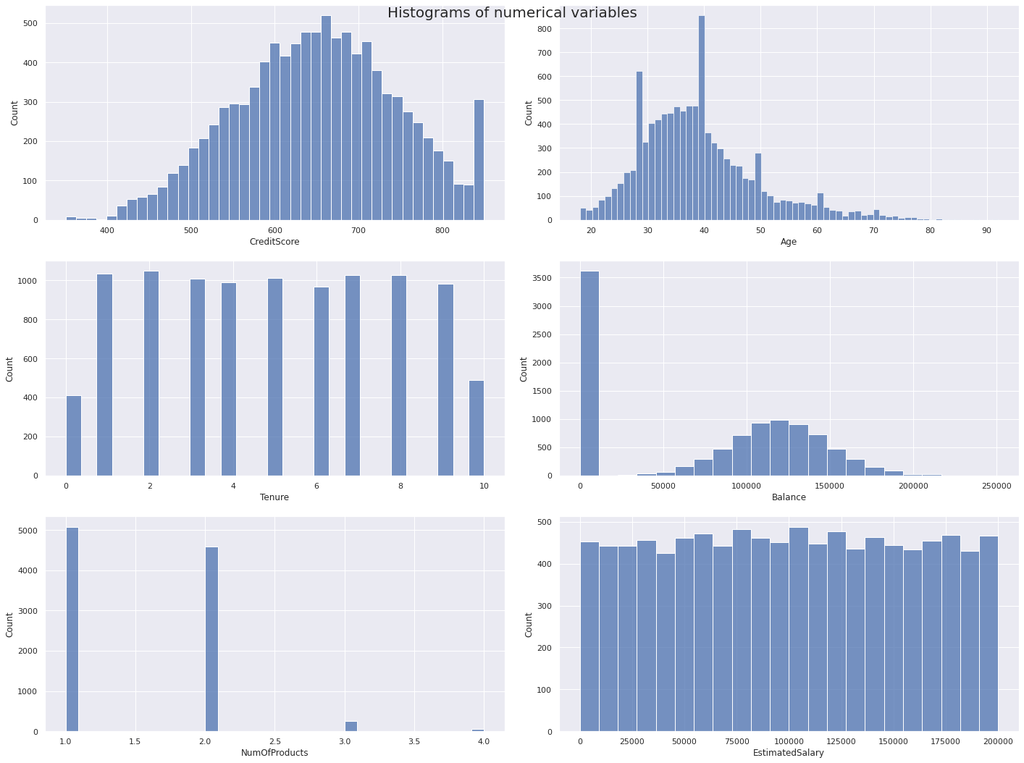

```python
fig, axes = plt.subplots(3, 2,  figsize=(20, 15))
fig.suptitle('Histograms of numerical variables', fontsize=20)
counter = 0
for ii in range(3):
    sns.histplot(ax=axes[ii][0],x=data[numerical_columns[counter]])
    counter = counter+1
    if counter != 6:
        sns.histplot(ax=axes[ii][1],x=data[numerical_columns[counter]])
        counter = counter+1
    else:
        pass

fig.tight_layout(pad=2.0)
```

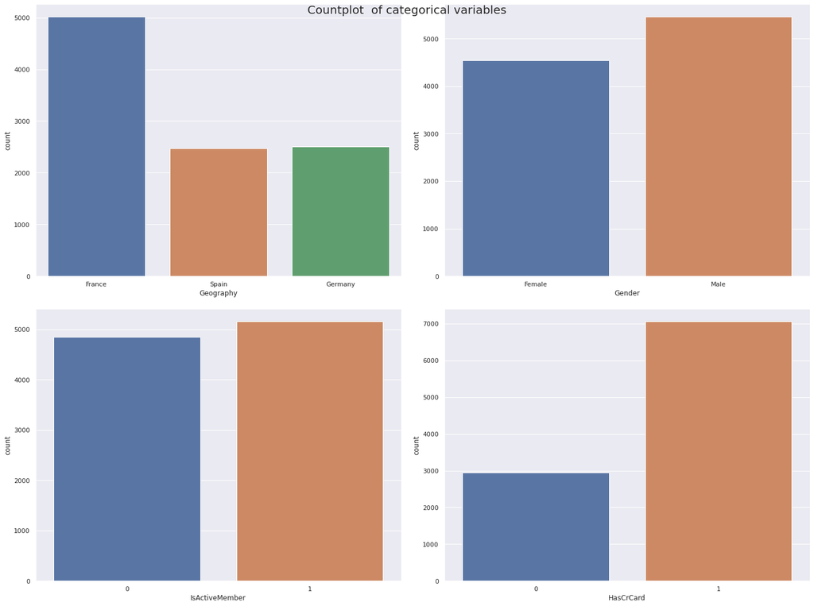

```python
fig, axes = plt.subplots(2, 2,  figsize=(20, 15))
fig.suptitle('Countplot  of categorical variables', fontsize=20)
counter = 0
for ii in range(2):
    sns.countplot(ax=axes[ii][0],x=data[categorical_columns[counter]])
    counter = counter+1
    if counter != 2:
        sns.countplot(ax=axes[ii][1],x=data[categorical_columns[counter]])
        counter = counter+1
    else:
        pass

fig.tight_layout(pad=2.0)
```

[output not shown]

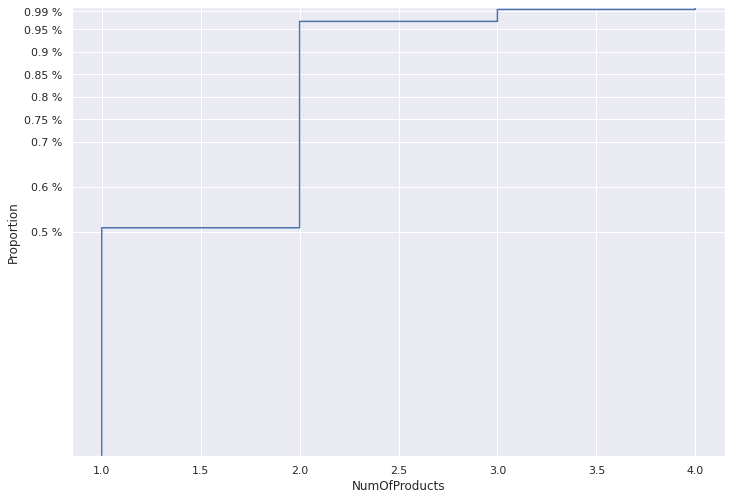

```python
sns.set(rc={'figure.figsize':(11.7,8.27)})

y_ticks = [0.5, 0.6, 0.7, 0.75, 0.8, 0.85, 0.9, 0.95, 0.99]
y_ticklabels = [f'{t} %' for t in y_ticks]

ax = sns.ecdfplot(x=data.NumOfProducts)

ax.yaxis.set_ticks(y_ticks)
ax.yaxis.set_ticklabels(y_ticklabels)
```

## Buvariate analysis

```
['CreditScore', 'Age', 'Tenure', 'Balance', 'NumOfProducts', 'EstimatedSalary', 'Exited']
```

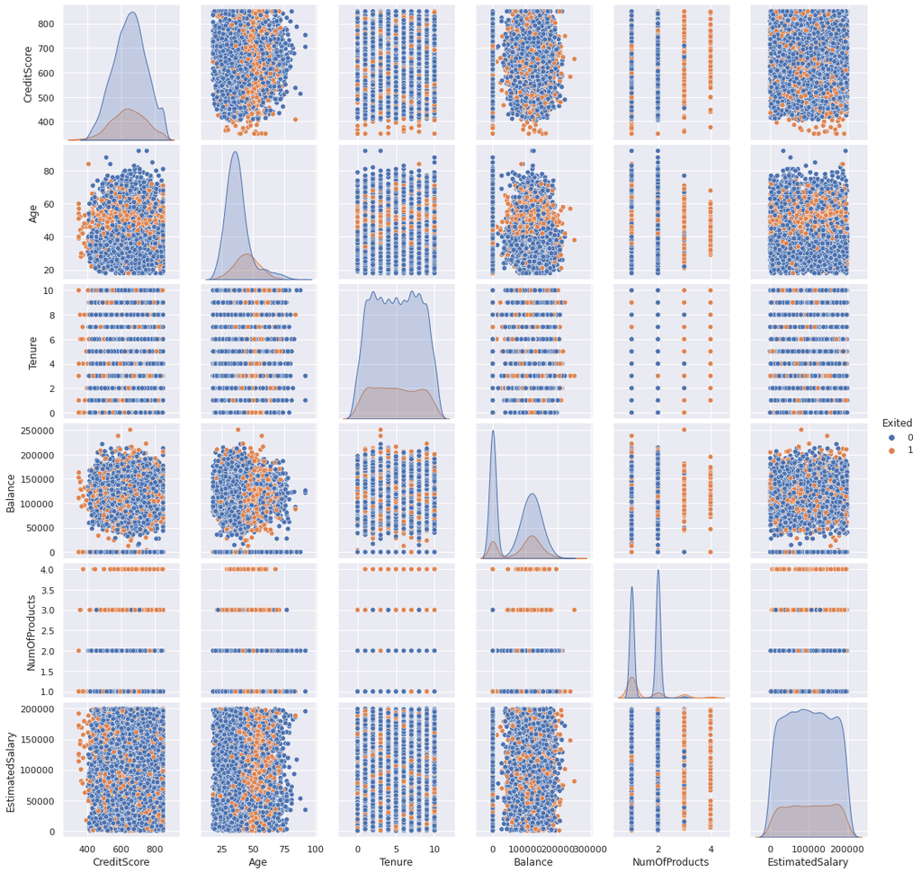

```python
nc = numerical_columns.copy()
nc.append(y_column)
print(nc)
sns.pairplot(data[nc], hue=y_column)
```

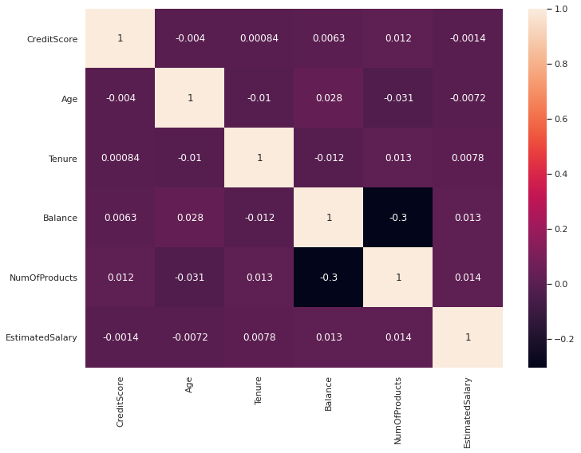

```python
sns.heatmap(data[numerical_columns].corr(), annot=True)
```

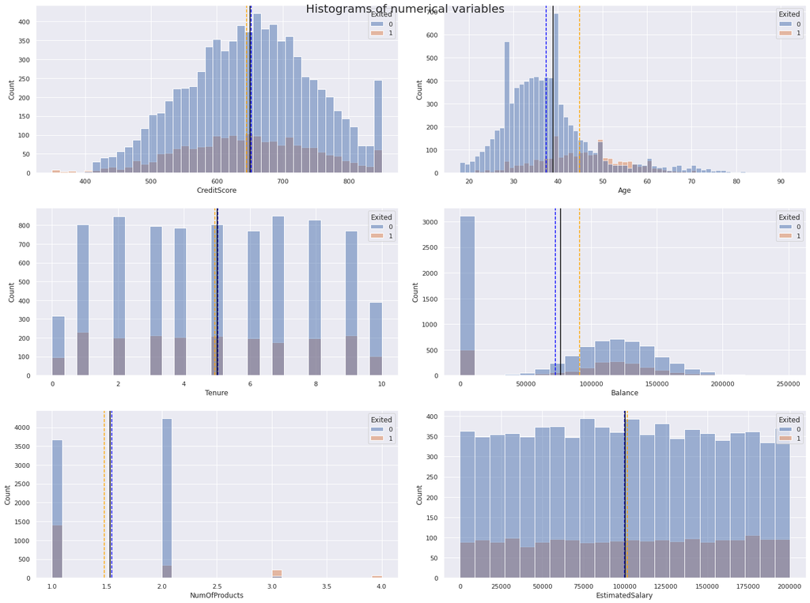

```python
fig, axes = plt.subplots(3, 2,  figsize=(20, 15))
fig.suptitle('Histograms of numerical variables', fontsize=20)
counter = 0
for ii in range(3):
    sns.histplot(data=data, ax=axes[ii][0],x=numerical_columns[counter], hue=y_column)
    mean0 = data[data['Exited'] == 0][numerical_columns[counter]].mean()
    mean1 = data[data['Exited'] == 1][numerical_columns[counter]].mean()
    mean  = data[numerical_columns[counter]].mean()
    axes[ii][0].axvline(x=mean0,color='blue',linestyle='--')
    axes[ii][0].axvline(x=mean1,color='orange',linestyle='--')
    axes[ii][0].axvline(x=mean ,color='black',linestyle='-')
    counter = counter+1
    if counter != 6:
        sns.histplot(data=data, ax=axes[ii][1],x=numerical_columns[counter], hue=y_column)
        mean0 = data[data['Exited'] == 0][numerical_columns[counter]].mean()
        mean1 = data[data['Exited'] == 1][numerical_columns[counter]].mean()
        mean  = data[numerical_columns[counter]].mean()
        axes[ii][1].axvline(x=mean0,color='blue',linestyle='--')
        axes[ii][1].axvline(x=mean1,color='orange',linestyle='--')
        axes[ii][1].axvline(x=mean ,color='black',linestyle='-')
        counter = counter+1
    else:
        pass

fig.tight_layout(pad=2.0)
```

Let's take a closer look at the tails of some distributions

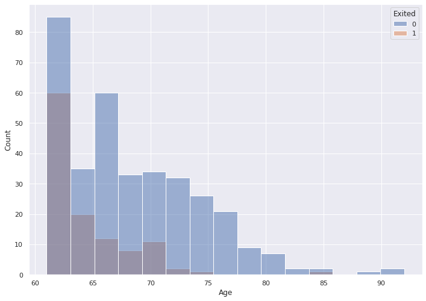

```python
sns.histplot(data=data[data['Age'] > 60], x='Age', hue=y_column)
```

```python
data[(data['Age']> 75) & (data['Exited'] == 1)]
```

|  | CreditScore | Geography | Gender | Age | Tenure | Balance | NumOfProducts | HasCrCard | IsActiveMember | EstimatedSalary | Exited |
| --- | --- | --- | --- | --- | --- | --- | --- | --- | --- | --- | --- |
| 3531 | 408 | France | Female | 84 | 8 | 87873.39 | 1 | 0 | 0 | 188484.52 | 1 |

```python
data[data['Age'] == 84]
```

|  | CreditScore | Geography | Gender | Age | Tenure | Balance | NumOfProducts | HasCrCard | IsActiveMember | EstimatedSalary | Exited |
| --- | --- | --- | --- | --- | --- | --- | --- | --- | --- | --- | --- |
| 3387 | 537 | Germany | Male | 84 | 8 | 92242.34 | 1 | 1 | 1 | 186235.98 | 0 |
| 3531 | 408 | France | Female | 84 | 8 | 87873.39 | 1 | 0 | 0 | 188484.52 | 1 |

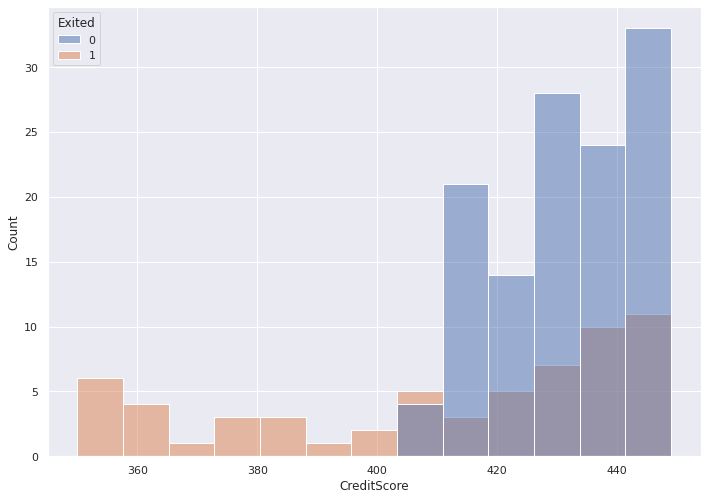

```python
sns.histplot(data=data[data['CreditScore'] < 450], x='CreditScore', hue=y_column)
```

```python
data[data['Exited'] == 0]['CreditScore'].min()
```

```
405
```

```python
def stacked_plot(x,y):
    #sns.set(palette='nipy_spectral')
    tab1 = pd.crosstab(data[x],data[y],margins=True)
    print(tab1)
    print('-'*120)
    tab = pd.crosstab(data[x],data[y],normalize='index')
    tab.plot(kind='bar',stacked=True,figsize=(10,5))
    plt.legend(loc='lower left', frameon=False)
    plt.legend(loc="upper left", bbox_to_anchor=(1,1))
    plt.show()
```

```
Exited            0     1    All
NumOfProducts
1              3675  1409   5084
2              4242   348   4590
3                46   220    266
4                 0    60     60
All            7963  2037  10000
------------------------------------------------------------------------------------------------------------------------
```

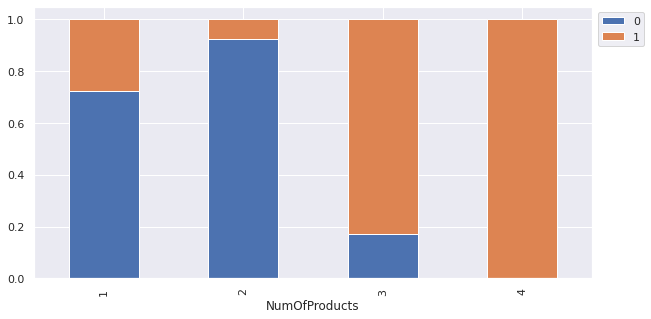

```python
stacked_plot('NumOfProducts', 'Exited')
```

Explore categorical columns

```
Exited        0     1    All
Geography
France     4204   810   5014
Germany    1695   814   2509
Spain      2064   413   2477
All        7963  2037  10000
------------------------------------------------------------------------------------------------------------------------
```

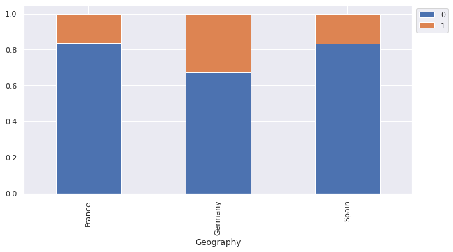

```
Exited     0     1    All
Gender
Female  3404  1139   4543
Male    4559   898   5457
All     7963  2037  10000
------------------------------------------------------------------------------------------------------------------------
```

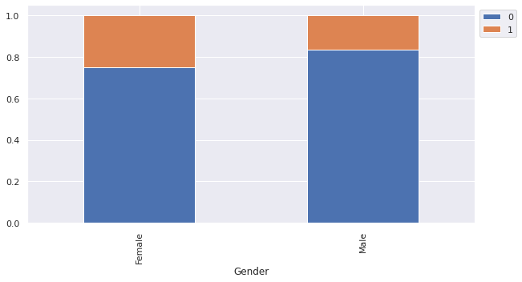

```
Exited             0     1    All
IsActiveMember
0               3547  1302   4849
1               4416   735   5151
All             7963  2037  10000
------------------------------------------------------------------------------------------------------------------------
```

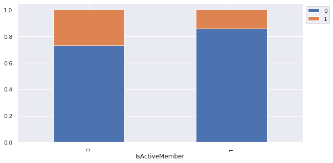

```
Exited        0     1    All
HasCrCard
0          2332   613   2945
1          5631  1424   7055
All        7963  2037  10000
------------------------------------------------------------------------------------------------------------------------
```

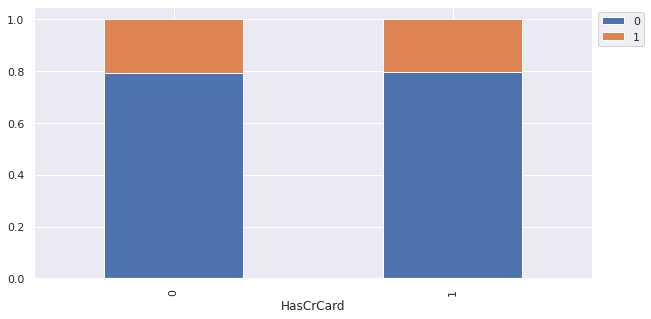

```python
for col in categorical_columns:
  stacked_plot(col,y_column)
```

# Illustrate the insights based on EDA

- Age is right skewed. There are very few customers of age 75+ for obvious reasons. There is only one Exited customer older then 75. She is 84, and there are only 2 cutomers of age 84. We will change age of all these customers 75+ to 76 to avoid model triggering on age 84
- All customers with credit score below 405 exited. We will change credit score below 410 to exactly 410 to avoid model overfitting on left tail of Credit score distribution
- 95% of customers have 1 or 2 products. Only 0.5% os customers have 4 products. All customers with 4 products exited, but there are very few of them. We will merge customers with 3 and 4 products to avoid model overfitting on customers with 4 products
- Behaviour of customers varies significantly depending on number of products. Customers with 2 products are most loyal, customers with 3 and 4 products are least loyal; customers with 1 product are somwhere in between. NumOfProducts looks more like categorical variable now.
- Females exit more often then males
- Customers from Germany exit more often then customers from Spain and France
- Active members exit less frequently
- While mean customer age is ~39, mean age of exiting customers is ~45
- While mean balance is ~75K, mean balance of exiting customers is ~90-95K
- There is no strong linear correlation between numerical features

# Data Pre-processing

- Split the variable and predictors
- Split the data into train and test
- Rescale the data

Process right tail of the Age distribution

```python
data2 = data.copy()
```

```python
process_outliers = 1
```

```python
if process_outliers:
  data2['Age'] = data['Age'].apply(lambda x: x if x < 76 else 76)
```

```python
data2.Age.max()
```

```
76
```

Process left tail of CreditScore distribution

```python
if process_outliers:
  data2['CreditScore'] = data['CreditScore'].apply(lambda x: x if x > 410 else 410)
data2.CreditScore.min()
```

```
410
```

Merge customers with 3 and 4 products into one category

```python
if process_outliers:
  data2['NumOfProducts'] = data['NumOfProducts'].apply(lambda x : x if x < 3 else 3)
data2.NumOfProducts.max()
```

```
3
```

Encode categorical columns

```python
categorical_columns = ['Geography', 'Gender', 'IsActiveMember', 'HasCrCard',
               'NumOfProducts']
numerical_columns = ['CreditScore', 'Age', 'Tenure', 'Balance',
       'EstimatedSalary']
```

```python
for col in categorical_columns:
  data2[col] = data2[col].astype('category')
```

```python
data2.info()
```

```
<class 'pandas.core.frame.DataFrame'>
RangeIndex: 10000 entries, 0 to 9999
Data columns (total 11 columns):
 #   Column           Non-Null Count  Dtype
---  ------           --------------  -----
 0   CreditScore      10000 non-null  int64
 1   Geography        10000 non-null  category
 2   Gender           10000 non-null  category
 3   Age              10000 non-null  int64
 4   Tenure           10000 non-null  int64
 5   Balance          10000 non-null  float64
 6   NumOfProducts    10000 non-null  category
 7   HasCrCard        10000 non-null  category
 8   IsActiveMember   10000 non-null  category
 9   EstimatedSalary  10000 non-null  float64
 10  Exited           10000 non-null  int64
dtypes: category(5), float64(2), int64(4)
memory usage: 518.2 KB
```

```python
for col in categorical_columns:
  data2 = pd.get_dummies(data2,prefix=col, columns =[col], drop_first=True)
```

```python
data2.sample(10)
```

|  | CreditScore | Age | Tenure | Balance | EstimatedSalary | Exited | Geography_Germany | Geography_Spain | Gender_Male | IsActiveMember_1 | HasCrCard_1 | NumOfProducts_2 | NumOfProducts_3 |
| --- | --- | --- | --- | --- | --- | --- | --- | --- | --- | --- | --- | --- | --- |
| 3773 | 749 | 35 | 3 | 0.00 | 132649.85 | 0 | 0 | 0 | 0 | 1 | 1 | 0 | 1 |
| 3000 | 532 | 40 | 5 | 0.00 | 177099.71 | 0 | 0 | 0 | 0 | 1 | 0 | 1 | 0 |
| 4773 | 646 | 35 | 1 | 121952.75 | 142839.82 | 0 | 1 | 0 | 0 | 1 | 1 | 1 | 0 |
| 8917 | 642 | 62 | 7 | 0.00 | 61120.75 | 0 | 0 | 0 | 1 | 1 | 1 | 1 | 0 |
| 1570 | 717 | 49 | 1 | 110864.38 | 124532.90 | 1 | 0 | 1 | 0 | 1 | 1 | 1 | 0 |
| 9430 | 753 | 33 | 5 | 122568.05 | 82820.85 | 0 | 0 | 0 | 1 | 1 | 1 | 1 | 0 |
| 2572 | 711 | 58 | 9 | 91285.13 | 26767.85 | 0 | 0 | 0 | 1 | 1 | 1 | 1 | 0 |
| 5462 | 694 | 29 | 5 | 99713.87 | 112317.89 | 0 | 0 | 0 | 0 | 0 | 0 | 0 | 0 |
| 212 | 620 | 41 | 9 | 0.00 | 88852.47 | 0 | 0 | 0 | 0 | 0 | 0 | 1 | 0 |
| 2299 | 650 | 25 | 2 | 114330.95 | 25325.07 | 0 | 1 | 0 | 0 | 1 | 1 | 0 | 0 |

Divide X and Y into training, validation and test set

```python
y = data2['Exited']
X = data2.drop(['Exited'], axis=1)
```

```python
X.columns
```

```
Index(['CreditScore', 'Age', 'Tenure', 'Balance', 'EstimatedSalary',
       'Geography_Germany', 'Geography_Spain', 'Gender_Male',
       'IsActiveMember_1', 'HasCrCard_1', 'NumOfProducts_2',
       'NumOfProducts_3'],
      dtype='object')
```

Split dataset: 60% - training data set, 20% - validation data set and 20% test data set

```python
from sklearn.model_selection import train_test_split
```

```python
 X_train, X_test, y_train, y_test \
    = train_test_split(X, y, test_size=0.2, random_state=1)

 X_train, X_val, y_train, y_val \
    = train_test_split(X_train, y_train, test_size=0.25, random_state=1) # 0.25 x 0.8 = 0.2
```

```python
print(X_train.shape, y_train.shape)
```

```
(6000, 12) (6000,)
```

```python
y_train.value_counts()
```

```
0    4793
1    1207
Name: Exited, dtype: int64
```

```python
y_test.value_counts()
```

```
0    1585
1     415
Name: Exited, dtype: int64
```

```python
#!pip install imbalanced-learn
```

Our classes are imbalanced. Use oversamplimg to balance them

```python
upsample = 1

from imblearn.over_sampling import RandomOverSampler

if upsample:
  oversample = RandomOverSampler(sampling_strategy='minority')
  X_train, y_train = oversample.fit_resample(X_train, y_train)
```

Rescale the data

```python
from sklearn.preprocessing import StandardScaler
from sklearn.preprocessing import MinMaxScaler
```

```python
scaler = StandardScaler()
#scaler=MinMaxScaler()
X_train_scaled = scaler.fit_transform(X_train)
X_test_scaled  = scaler.transform(X_test)
X_val_scaled  = scaler.transform(X_val)
```

```python
X_train_np = X_train_scaled
if upsample == 0:
  y_train_np = y_train.to_numpy()
else:
  y_train_np = y_train

X_test_np = X_test_scaled
y_test_np = y_test.to_numpy()
X_val_np = X_val_scaled
y_val_np = y_val.to_numpy()
```

# Model building

- Build Neural Network

### Define some helper functions

```python
import numpy as np
import tensorflow as tf
import random as python_random

def random_seed(seed = 123):

  # The below is necessary for starting Numpy generated random numbers
  # in a well-defined initial state.
  np.random.seed(seed)

  # The below is necessary for starting core Python generated random numbers
  # in a well-defined state.
  python_random.seed(seed)

  # The below set_seed() will make random number generation
  # in the TensorFlow backend have a well-defined initial state.
  # For further details, see:
  # https://www.tensorflow.org/api_docs/python/tf/random/set_seed
  tf.random.set_seed(seed)
```

Function below builds neural network

- Caller should provide number of hidden layers, number of nodes per hidden layer, optimizer, batch size, number of epochs and multiplier for default learning rate (since default LR are different for different optimizers)
- In the beginning of the proc we call random_seed() to reproduce the same results between runs
- We use dropouts to help prevent overfitting. Dropout rate is also provided by the caller
- We use training set to train NN and validation set for performance validation during training. Test set is used for evaluation of model performance when training is done

```python
def buildNeuralNetwork(n_layers, n_nodes, activation, loss_f, optimizer,
                       lr_mult, batch, epochs, X, y, n_inputs, do_rate,
                       callbacks, verbose):
  random_seed()
  model = Sequential()
  #input layer
  model.add(ks.Input(shape = (n_inputs,)))
  #alternative input layer
  #model.add(Dense(n_nodes, input_shape=(n_inputs, ), kernel_initializer='he_normal', activation='relu'))
  #hidden layers
  n_nodes_layer = n_nodes * 1.5
  for i in range(0, n_layers):
    n_nodes_layer /= 1.5
    model.add(Dense(n_nodes_layer, activation=activation))
    if do_rate  > 0:
      model.add(Dropout(do_rate))
  #output layer
  model.add(Dense(1, activation='sigmoid'))

  sample_weight = np.ones(shape=(len(y),))
  sample_weight[y == 1] = 4

  opt = optimizer

  old_lr = optimizer.get_config()['learning_rate']
  new_lr = old_lr * lr_mult
  opt.learning_rate.assign(new_lr)
  print("Change LR from {} to {}".format(old_lr, opt.learning_rate))

  metrics = [
    ks.metrics.FalseNegatives(name="fn"),
    ks.metrics.FalsePositives(name="fp"),
    ks.metrics.TrueNegatives(name="tn"),
    ks.metrics.TruePositives(name="tp"),
    ks.metrics.Precision(name="precision"),
    ks.metrics.Recall(name="recall"),
    ks.metrics.AUC(name='AUC'),
    ks.metrics.PrecisionAtRecall(0.7, name='PaR'),
 ]

  model.compile(optimizer=opt,
              loss=loss_f,
              metrics=metrics,
              )
  #history = model.fit(X, y, epochs=epochs, batch_size=batch, verbose=verbose,
  #          sample_weight=sample_weight, validation_split=0.25,
  #          callbacks = callbacks)
  history = model.fit(X, y, epochs=epochs, batch_size=batch, verbose=verbose,
            sample_weight=sample_weight, validation_data=(X_val_np, y_val_np),
            callbacks = callbacks)

  ##restore learning rate
  opt.learning_rate.assign(old_lr)
  return model, history
```

calc_custom_metric calculates custom metric for model performance estimation. It will be explained below

```python
recall_weight = 2
## Custom metric: see explanation below

def calc_custom_metric(y, y_pred):
  tn, fp, fn, tp = skmetrics.confusion_matrix(y, y_pred).ravel()
  tpr = tp / (tp + fn)
  fpr = fp / (fp + tn)
  custom = (1 + recall_weight * tpr - fpr) / (recall_weight + 1)
  return custom

def get_model_metrics (model, x, y, threshold, out):
  y_pred = model.predict(x)
  y_pred = y_pred[:,0]
  step_f = lambda x : 0 if x < threshold else 1
  y_pred = np.array([step_f(xi) for xi in y_pred])


  recall, precision, f1, cm, custom = \
           skmetrics.recall_score(y, y_pred), \
           skmetrics.precision_score(y, y_pred),\
           skmetrics.f1_score(y, y_pred),\
           skmetrics.confusion_matrix(y, y_pred), \
           calc_custom_metric(y, y_pred)
  if (out):
    print ("Recall: {0:.2}, Precision: {1:.2}, f1:{2:.2}, custom metric:{3:.2}:".format(recall, precision, f1, custom))

  return recall, precision, f1, cm, custom
```

Functions in the below cell are used to calculate optimal threshold using custom metric

```python
def find_nearest(array, value):
    array = np.asarray(array)
    idx = (np.abs(array - value)).argmin()
    return idx

def find_best_threshold(y, y_pred):
  fpr, tpr, thresholds = skmetrics.roc_curve(y, y_pred)

  optimal_idx = np.argmax((recall_weight * tpr - fpr))
  return thresholds[optimal_idx]
```

Some functions for data visualization

```python
def make_confusion_matrix(cm,labels=[1, 0]):
    df_cm = pd.DataFrame(cm, index = [i for i in ["Actual - Loyal","Actual - Exited"]],
                  columns = [i for i in ['Predicted - Loyal','Predicted - Exited']])
    group_counts = ["{0:0.0f}".format(value) for value in
                cm.flatten()]
    group_percentages = ["{0:.2%}".format(value) for value in
                         cm.flatten()/np.sum(cm)]
    labels = [f"{v1}\n{v2}" for v1, v2 in
              zip(group_counts,group_percentages)]
    labels = np.asarray(labels).reshape(2,2)
    plt.figure(figsize = (10,7))
    sns.heatmap(df_cm, annot=labels,fmt='')
    plt.ylabel('True label')
    plt.xlabel('Predicted label')
```

```python
def plot_history(history,  keys):
  for key in keys:
    plt.plot(history.history[key])
    plt.plot(history.history['val_'+key])
    plt.ylabel(key)
    plt.xlabel('epoch')
    plt.legend(['train','test'], loc='upper left')
    plt.show()
```

```python
def plot_roc_auc(model, X, y, best_th=-1):
  y_pred=model.predict(X)[:,0]
  fpr_keras, tpr_keras, thresholds_keras = skmetrics.roc_curve(y, y_pred)
  auc_keras = skmetrics.auc(fpr_keras, tpr_keras)
  plt.figure(1)
  plt.plot([0, 1], [0, 1], 'k--')
  plt.plot(fpr_keras, tpr_keras, label='Keras (area = {:.3f})'.format(auc_keras))
  plt.xlabel('False positive rate')
  plt.ylabel('True positive rate')
  plt.title('ROC curve')
  if (best_th >= 0) :
    best_idx = find_nearest(thresholds_keras, best_th)
    best_x = fpr_keras[best_idx]
    best_y = tpr_keras[best_idx]
    plt.plot(best_x, best_y, 'ro', label='Best score')
  plt.legend(loc='best')
  plt.show()
  plt.show()
```

```python
def plot_precision_recall(model, X, y, best_th):
  y_pred=model.predict(X)[:,0]
  pr_keras, rc_keras, thresholds_keras = skmetrics.precision_recall_curve(y, y_pred)
  plt.figure(1)
  plt.plot(pr_keras, rc_keras, label='Precision vs Recall')
  plt.xlabel('Precision')
  plt.ylabel('Recall')
  plt.title('Precision-Recall curve')
  if (best_th >= 0) :
    best_idx = find_nearest(thresholds_keras, best_th)
    best_x = pr_keras[best_idx]
    best_y = rc_keras[best_idx]
    plt.plot(best_x, best_y, 'ro', label='Best score')
  plt.legend(loc='best')
  plt.show()
  plt.show()
```

## Initialize neural network parameters and build a neural network

```python
n_layers = 5
n_nodes = 150
activation = 'relu'
loss_f=ks.losses.BinaryCrossentropy()
optimizer = ks.optimizers.Adam()
mult = 1
batch = 2000
n_inputs = X.columns.size
callbacks = None
do_rate = 0.2
epochs = int(do_rate * 2000)
verbose = 0
```

```python
model_results  = []
```

```python
model,history = buildNeuralNetwork(n_layers, n_nodes, activation, loss_f, optimizer, mult, batch,
                   epochs, X_train_np, y_train_np,
                   n_inputs, do_rate, callbacks, verbose)
```

```
Change LR from 0.001 to <tf.Variable 'learning_rate:0' shape=() dtype=float32, numpy=0.001>
```

```python
r, p, f1, cm, custom = get_model_metrics(model, X_train_np, y_train_np, 0.5, 1)
```

```
Recall: 1.0, Precision: 0.89, f1:0.94, custom metric:0.96:
```

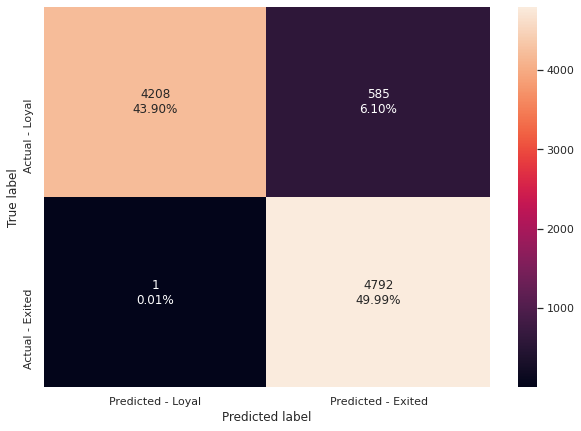

```python
make_confusion_matrix(cm)
```

Excellent performance on training set

```python
history.history.keys()
```

```
dict_keys(['loss', 'fn', 'fp', 'tn', 'tp', 'precision', 'recall', 'AUC', 'PaR', 'val_loss', 'val_fn', 'val_fp', 'val_tn', 'val_tp', 'val_precision', 'val_recall', 'val_AUC', 'val_PaR'])
```

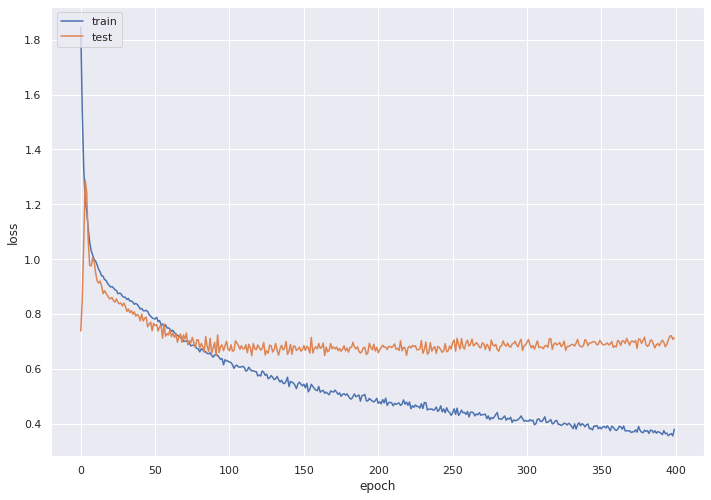

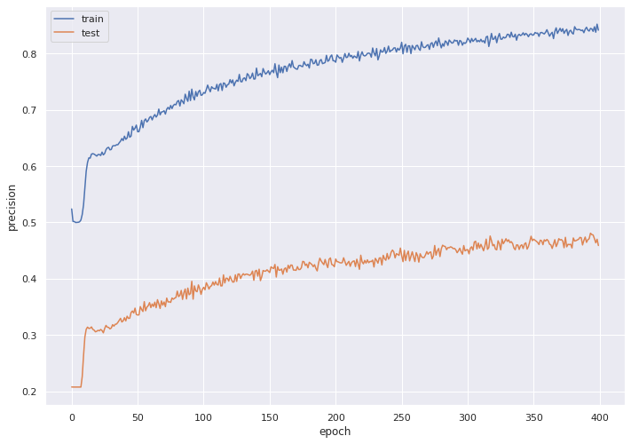

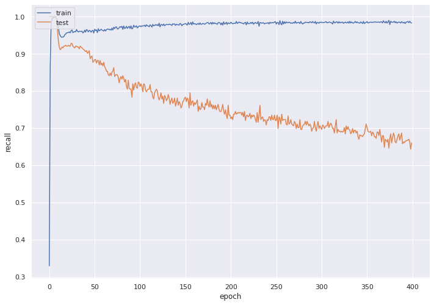

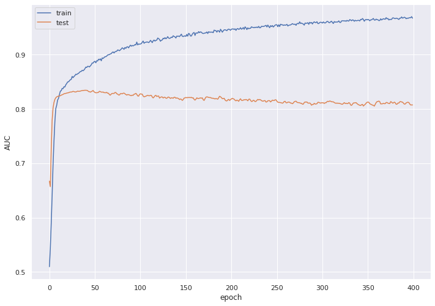

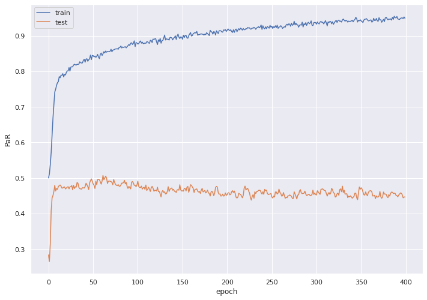

```python
plot_history(history, ['loss', 'precision', 'recall', 'AUC', 'PaR'])
```

- Loss function for validation set stopped decreasing at ceratin epoch
- There are oscilations of Loss function which can indicate that learning rate is too large

```python
r, p, f1, cm, custom = get_model_metrics(model, X_test_np, y_test_np, 0.5, 1)
```

```
Recall: 0.71, Precision: 0.49, f1:0.58, custom metric:0.74:
```

```python
result = {'name': 'First try', 'recall' : r, 'precision': p, 'f1_score': f1, 'custom_metric': custom}
model_results.append(result)
```

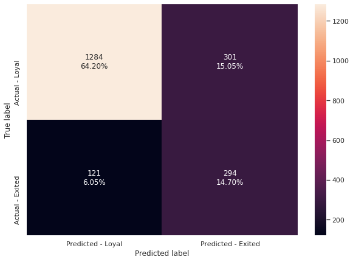

```python
make_confusion_matrix(cm)
```

# Model Performance Improvement

- Comment on which metric is right for model performance evaluation and why?
- Find the optimal threshold using ROC-AUC or Precision-Recall curves
- Comment on model performance
- Can model performance be improved? check and comment
- Build another model to implement these improvements
- Include all the model which were trained to reach at the final one

Let's see how probabilities are distributed on validation set

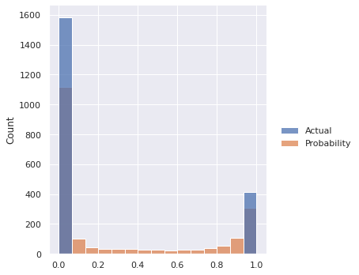

```python
y_pred=model.predict(X_val_np)[:,0]
sns.displot(data={'Actual':y_val_np, 'Probability': y_pred})
```

Threshold can be changed to make model performance better. Before finding the optimal threshold we should decide what metric we are going to use

Loosing a customer has a big impact on bank and we should identify as many of exiting customers as possible, which means True Positive Rate a.k.a. Recall should be maximized. But NN can maximize recall by simply identify all the customers as Exiting. To prevent that we should penalize our metric for every loyal customer identified as exiting. \begin{equation} metric= w_{recall} * TPR - FPR \end{equation} $w_{recall}$ is a weight of an Exiting customer compared to the weight of a loyal customer. For example, if identifying of exiting customer is twice as important as identifying a loyal customer, then $w_{recall} = 2$. This metric is in range of [-1, $w_{recall} - 1$]. In order to place it in [0,1] range we should modify metric as follows: \begin{equation} metric= \frac{(1 + w_{recall} * TPR - FPR)}{1+w_{recall}} \end{equation} This metric is calculated by finction *calc_custom_metric*. Custom Test data score for the original NN is 0.74

```python
y_pred=model.predict(X_val_np)[:,0]
pr, rc, thresholds_keras = skmetrics.precision_recall_curve(y_val_np, y_pred)

#f1 = 2 * (pr * rc) / (pr + rc)
#idx = find_nearest(f1, f1.max())

new_th = find_best_threshold(y_val_np, y_pred)
idx = find_nearest(thresholds_keras, new_th)

print ("{} Precision={}, Recall={}, Threshold={}".format(idx, pr[idx], \
                  rc[idx], thresholds_keras[idx]))
```

```
1045 Precision=0.36477987421383645, Recall=0.8385542168674699, Threshold=0.043207257986068726
```

```python
#metrics = []
#for th in thresholds_keras:
#  r, p, f1, cm, custom =  get_model_metrics(model, X_val_np, y_val_np, th, 0)
#  metrics.append(custom)
```

```python
#  r, p, f1, cm, custom =  get_model_metrics(model, X_val_np, y_val_np, new_th, 0)
#
#  plt.figure(1)
#  plt.plot(thresholds_keras, metrics, label='metric')
#  plt.plot(new_th, custom, 'ro')
```

```python
new_th
```

```
0.043207258
```

Threshold has been changed. We should expect better performance in Exiting customer identification, and degradation in loyal customer idantification. Let's see where the new threshold is on ROC-AUC an Precision-Recall plots for test data

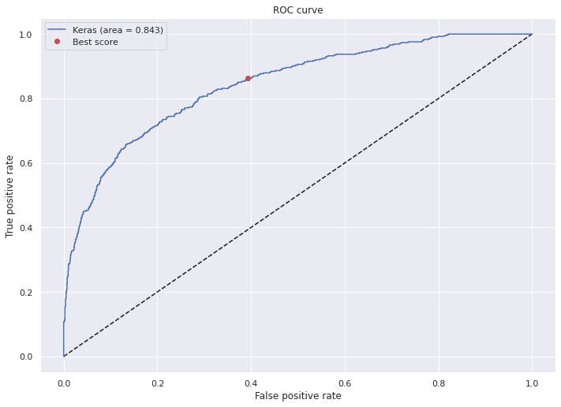

```python
plot_roc_auc(model, X_test_np, y_test_np, new_th)
```

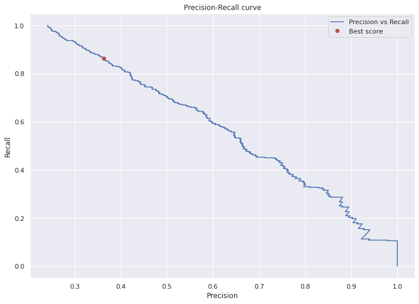

```python
plot_precision_recall(model, X_test_np, y_test_np, new_th)
```

```python
print('Test set')
print ('Metrics for default threshold:')
dummy = get_model_metrics(model, X_test_np, y_test_np, 0.5, 1)
print ('Metrics for new threshold ({0:.02}):'.format(new_th))
r, p, f1, cm, custom =  get_model_metrics(model, X_test_np, y_test_np, new_th, 1)
```

```
Test set
Metrics for default threshold:
Recall: 0.71, Precision: 0.49, f1:0.58, custom metric:0.74:
Metrics for new threshold (0.043):
Recall: 0.86, Precision: 0.36, f1:0.51, custom metric:0.78:
```

```python
result = {'name': 'First try with modified threshold', 'recall' : r, 'precision': p, 'f1_score': f1, 'custom_metric': custom}
model_results.append(result)
```

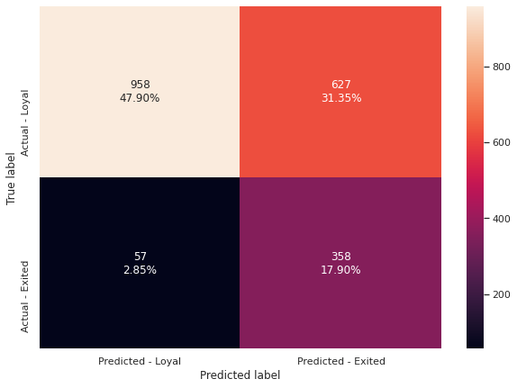

```python
make_confusion_matrix(cm)
```

With modified threshold we managed to identify additional exiting cutomers, but much more extra loyal customers were identified as exiting. Overall metric slighly increase or didn't change